# TanaySolanki_v3

## PART A

Setup:

```python
import numpy as np
import matplotlib.pyplot as plt
import pandas as pd

import shutil

import fnmatch
import os

import re

import torch
import torch.nn as nn
import torch.nn.functional as F
import torch.optim as optim
from torch.utils.data import DataLoader, Subset, TensorDataset

from torchvision import transforms, datasets
from torchvision.models import resnet18, ResNet18_Weights

from sklearn.metrics import (f1_score, accuracy_score, precision_score, recall_score,
                             roc_auc_score, confusion_matrix,
                             ConfusionMatrixDisplay)

from pathlib import Path
from PIL import Image

from collections import Counter

from itertools import cycle

device = torch.device('cuda' if torch.cuda.is_available() else 'cpu')
print('Using device: ', device)
torch.manual_seed(42)
```

```
Using device:  cuda
```

```
<torch._C.Generator at 0x7f390810a330>
```

Verifying Dataset Structure:

```python
# Code taken from AWS tutorial on Canvas

DATASET_ROOT = Path("../data_resized/")

pat = re.compile(r"^(?P<actor>[^_]+)_(?P<action>.+)_HD_instance(?P<instance>\d+)_(?P<frame>\d+)\.png$", re.I)

rows = []
for p in sorted(DATASET_ROOT.rglob("*.png")):
    if "_MACOSX" in p.parts or p.name.startswith("._"):
        continue  # ignore archive artefacts
    m = pat.match(p.name)
    if not m:
        continue
    rows.append(dict(
        path=str(p),
        gesture=p.relative_to(DATASET_ROOT).parts[0],  # label = top-level folder
        actor=m["actor"],
        instance=int(m["instance"]),
        frame=int(m["frame"]),
        instance_uid=f'{m["actor"]}|{p.relative_to(DATASET_ROOT).parts[0]}|{m["instance"]}',
    ))

df = pd.DataFrame(rows)
print(f"frames    : {len(df)}")
print(f"instances : {df['instance_uid'].nunique()}")
print(f"actors    : {df['actor'].nunique()}")
print(f"classes   : {df['gesture'].nunique()}")

# integrity check: every instance should have exactly 5 frames
bad = df.groupby("instance_uid")["frame"].nunique()
assert (bad == 5).all(), f"instances without exactly 5 frames: {bad[bad != 5].index.tolist()}"
print("OK: every instance has 5 frames")
```

```
frames    : 5295
instances : 1059
actors    : 11
classes   : 13
OK: every instance has 5 frames
```

Motivation:

RedKite Aerospace Australia as a drone-manufacturing startup, that is seeking a contract from a regional emergency-services provider.

The provider's request for proposal (RFP) is for a drone capable of delivering time-critical medical supplies, while also being capable of following marshalling-style gestures from the person receiving the supplies.

RedKite is therefore motivated to build a gesture-classifier for their drone platform. The onboard perception stack within the drone platform already has a segmenter, that first watches the reciever perform a gesture, and then extracts a five-frame instance.

Therefore, the classifier must be able to predict which of the **13 gestures** a given 5-frame instance belongs to.

Constraints:

- 2D convolutional backbones only. No recurrent models, no 3D convolutions, and no temporal-attention / video-transformer architectures.
- The model must run inference on one instance at a time on an embedded board, ensuring the operation is small enough that a real-time operation on a constrained hardware is plausible.
- ImageNet-pretrained backbones and standard augmentation are permitted. But pretraining on external gesture or action-recognition datasets is not allowed.

Literature review:

Preceeding the development of the classifier by researching existing experiments that have approached similar scenarios is worthwhile. Leveraging techniques that have already been discovered can save time, which can then be reinvested in optimizing towards our particular scenario.

Yu, J., Qin, M. & Zhou, S. Dynamic gesture recognition based on 2D convolutional neural network and feature fusion. Sci Rep 12, 4345 (2022). https://doi.org/10.1038/s41598-022-08133-z

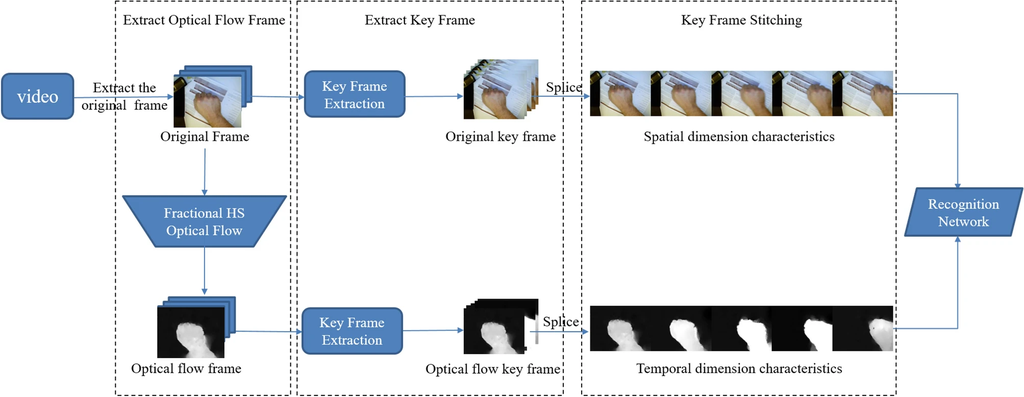

The figure above is an overview of the approach proposed by Yu, Qin and Zhou (2022). In their paper, Yu et. al. propose a 2D CNN that can classify hand signals from video data that has been restructured into two keyframes: one capturing "Spatial dimension characteristics", and another capturing "Temporal dimension characteristics". The pair of keyframes are then sent to a dual-channel 2D CNN for parallel feature extraction, followed by feature fusion, and eventually a soft-max classification layer.

Aspects of their approach that exist out-of-scope for our scenario include the preparation of a keyframe that captures "Temporal dimension characteristics", and their usage of publically available hand-gesture datasets for training their classifier. This consequently makes the design of their dual-channel, feature-fusion 2D-CNN incompatible with RedKite's goals, and an impermissable point of reference.

However, one strategy from this approach that can be leveraged is the preparation of a "Spatial dimension characteristics" keyframe. Simply put, this keyframe is the concatenation of 5 key frames, side-by-side.

Therefore, the 5 images extracted by the drone's onboard segmenter, will be concatenated into a long, horizontal image before being sent to the classifier that is to be developed.

Exploratory Data Analysis:

Observation:

- manual checking reveals a file structure as follows: ../data_resized/{class name}/{subject name}/{instance name}/{five-image group}

Decision:

- explore balance of subjects per class, instances per class, etc.
- the balance of the dataset will decide which subjects will be assigned to train/val/test sets are prepared, in order to optimize performance on unseen subjects

```python
from pathlib import Path

INPUT_DIR = Path('../data_resized/')
INPUT_DIR_NAME = INPUT_DIR.name

class_subject_counts = {}

for class_dir in INPUT_DIR.iterdir():

    # Ignore anything that isn't a directory
    if not class_dir.is_dir():
        continue

    # Find subject directories
    subject_dirs = [
        path for path in class_dir.iterdir()
        if path.is_dir() and path.name.startswith("S")
    ]

    class_subject_counts[class_dir.name] = len(subject_dirs)
```

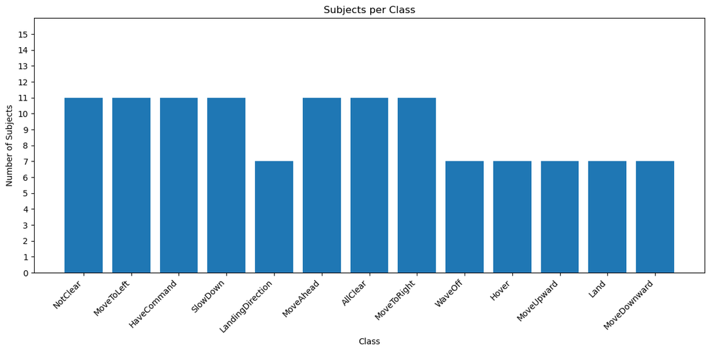

```python
import matplotlib.pyplot as plt

plt.figure(figsize=(12, 6))

plt.bar(
    class_subject_counts.keys(),
    class_subject_counts.values()
)

plt.xlabel("Class")
plt.ylabel("Number of Subjects")
plt.title("Subjects per Class")

plt.ylim(0, 16)
plt.yticks(range(0, 16))

plt.xticks(rotation=45, ha="right")

plt.tight_layout()
plt.show()
```

Observation:

- there seem to be 11 separate subjects
- not all classes have instances with all 11 subjects
- this could result in the 2D CNN performing more effectively upon unseen receivers of similar appearance (sex, build, complexion, hair, etc.) to most frequently appearing subjects in the dataset.

Decision:

- assess appearances of each subject to decide which appearance profile is potentially under-represented

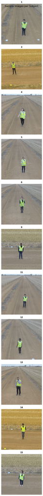

```python
from PIL import Image

subject_image_dict = {}
for i in range (1, 16):
    if i == 2 or i == 7 or i == 8 or i == 10:
        continue
    subject_image_dict[i] = f"../data_resized/AllClear/S{i}/Instance1/S{i}_allClear_HD_instance1_1.png"

subject_image_dict = dict(sorted(subject_image_dict.items()))
subject_samples = {}
for key in subject_image_dict:
    image_name = subject_image_dict[key]
    img = Image.open(image_name)
    subject_samples[key] = img

# Show sample images from each class
fig, axes = plt.subplots(11, 1, figsize=(16, 40))
fig.suptitle('Sample Images per Subject', fontsize=14)

# axes = axes.flatten()

col = 0
for key in subject_samples:
    axes[col].imshow(subject_samples[key])
    axes[col].axis('off')
    axes[col].set_title(f'{key}', fontsize=11, fontweight='bold')
    col += 1

plt.tight_layout()
plt.show()
```

Observation:

- the dataset shows fewer subjects with darker skin tones, compared to fairer skin tones
- all subjects are wearing green, hi-vis vests and dark-coloured pants. This may result in the 2D CNN performing worse on unseen receivers that don't have hi-vis vests and/or dark-coloured pants.
- seven subjects are facing "down" the road, which results in several vertical lines appearing in their background, while only four subjects are facing "across" the road, adding horizontal lines to their background. This may result in the 2D CNN performing better on receivers facing "down" similar dirt tracks, than when facing "across".
- subjects 3 and 14 have yellower backgrounds then the rest of the dataset, but the majority of subjects display a similar range in colours.
- the backgrounds are mostly uncluttered, which may make identifying the subject "easier" in training for the 2D CNN. This may result in weaker performance on receivers that have cluttered backgrounds.
- Subjects 4, 11 and 13 have horizons in their background, which adds new colour and a strong horizontal line to the frame. This might make classifying their gestures more challenging for the 2D CNN, especially as certain gestures may involve extending one's arms in a horizontal line as well. A horizon could potentially lead to a missclassification of a gesture as another with a stronger horizontal signal.

Decision:

- subjects with darker skin tones, such as S12, should be placed in the training set for better generalisability on unseen subjects of varying complexion
- acknowledge the likely limitation of the 2D CNN performing worse on unseen subjects without green, hi-vis vests, or those who have cluttered backgrounds.
- prioritise placing subjects facing "across" the road in the training data, to limit bias towards the majority case where subjects are facing "down" the road.
- ideally place subjects 3 and 14 in the training data to increase colour variety, and eventually use colour-based augmentation to further increase colour variety.
- ideally place subjects 4, 11 and 13 in training, to maximise performance of the 2D CNN on unseen subjects with horizons visible in their background.
- continue evaluating balance of instances per class, instances per subject, etc.

```python
data = []

for class_dir in INPUT_DIR.iterdir():

    if not class_dir.is_dir():
        continue

    class_name = class_dir.name

    for subject_dir in class_dir.iterdir():

        if not subject_dir.is_dir():
            continue

        subject = subject_dir.name

        # Count Instance folders
        instance_count = sum(
            1 for path in subject_dir.iterdir()
            if path.is_dir() and path.name.startswith("Instance")
        )

        data.append({
            "class": class_name,
            "subject": subject,
            "instances": instance_count
        })

df = pd.DataFrame(data)
```

```python
heatmap_data = df.pivot(
    index="class",
    columns="subject",
    values="instances"
)

subject_order = [f"S{i}" for i in range(1, 16)]

heatmap_data = (
    heatmap_data
        .reindex(columns=subject_order)
        .fillna(0)
)
```

```python
subject_order = [f"S{i}" for i in range(1, 16)]

classes_per_subject = (
    df.groupby("subject")["class"]
      .nunique()
      .reindex(subject_order, fill_value=0)
)
```

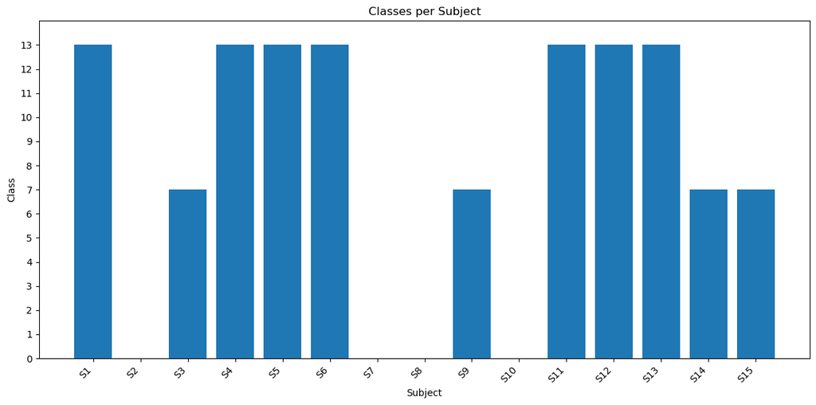

```python
plt.figure(figsize=(12, 6))

plt.bar(
    classes_per_subject.index,
    classes_per_subject.values
)

plt.xlabel("Subject")
plt.ylabel("Class")
plt.title("Classes per Subject")

plt.ylim(0, 14)
plt.yticks(range(0, 14))

plt.xticks(rotation=45, ha="right")
plt.tight_layout()
plt.show()
```

Observation:

- Subjects 1, 4-6, and 11-13 possess instances of them performing all 13 gestures

Decision:

- Of the subjects shortlisted, one of them should be in the validation set, and another should be in the testing set, while the rest go to the training set (while still respecting the other priority of putting as many darker-complexion subjects in the training set as possible)
- To further inform the decision of which of these subjects should be used for train/val/test sets, explore the number of instances contributed by each subject

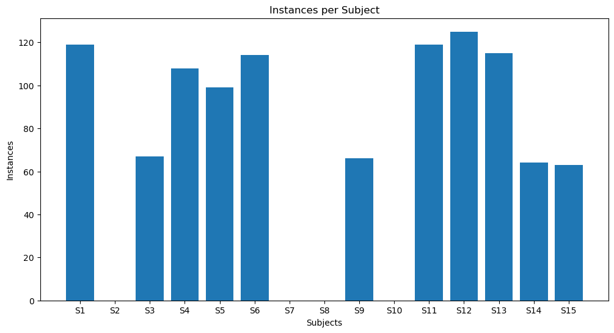

```python
subject_instance_count = heatmap_data.sum(axis=0)

plt.figure(figsize=(12, 6))

plt.bar(
    subject_instance_count.index,
    subject_instance_count.values
)

plt.title("Instances per Subject")
plt.xlabel("Subjects")
plt.ylabel("Instances")

plt.show()
```

Observation:

- Subjects 1, 4-6, and 11-13 contribute the most data

Decision:

- Prioritise placing as many of these subjects in the training set as possible, to maximise data for the 2D CNN.

Final Decision for Data Splitting:

- Subject 12 must be in the training set, being the only person with their complexion in the dataset, to maximise performance on unseen subjects of similar complexion.
- Subjects 3, 9, 14 and 15 should also be in the training set, as they represent the only subjects facing across the road, therefore doing so maximises performance on similar unseen subjects. Furthermore, 3 and 14 have the yellower backgrounds. Also, these four subjects also lack complete coverage of all 13 classes in their contribution to the dataset, and therefore would be ineffective in validating and testing classification performance across all 13 classes.
- Subjects 4, 11, 13 should be in the training set, due to the presence of horizons in their backgrounds.
- This leaves subjects 1, 5, and 6. Subject 1 contributes the most samples of these three, so they should be added to the training dataset to maximise size.
- So, subject 5 will represent the validation set, and subject 6 will represent the test set.

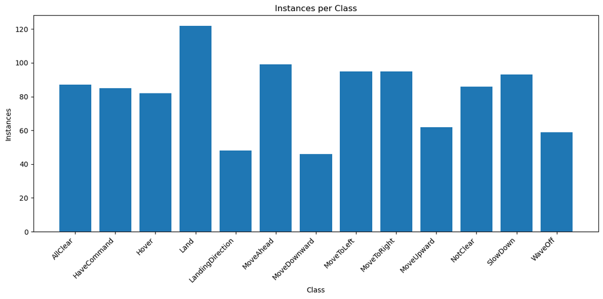

```python
class_instance_count = heatmap_data.sum(axis=1)
plt.figure(figsize=(12, 6))

plt.bar(
    class_instance_count.index,
    class_instance_count.values
)

plt.xlabel("Class")
plt.ylabel("Instances")
plt.title("Instances per Class")

plt.xticks(rotation=45, ha="right")
plt.tight_layout()
plt.show()
```

Observation:

- the dataset is very small, with the largest class only having ~120 samples, and the smallest having as few as ~40 samples. A basic 2D CNN could easily memorise a dataset this small, and fail to generalise well on unseen receivers.
- the dataset is unbalanced, which may result in more frequent missclassification of minority classes, such as "LandingDirection" and "MoveDownward", as well as over-classification of majority classes such as "Land".

Decision:

- Transfer learning will be used for the baseline model, with a lightweight model selected to minimize parameter count. Minimising the size of the model is a priority for manageable performance on the contstrained hardware of RedKite's drone platform. ResNet-18 will be selected as a suitable backbone for the baseline model, for meeting the constraint of being trained on the ImageNet dataset, and for its relatively small size.
- Class-weighted Cross Entropy Loss should be used for calculating loss when training the 2D CNN, to increase loss accrued when missclassifying a minority class sample. This should increase metrics such as precision, recall and macro f1-score.
- Macro f1-score should be the guiding metric for the iterative development of the 2D CNN, as it combines aspects of precision and recall to display how performant the network is on minority classes. Maximising Macro F1-score is a preferred main metric to accuracy, as it has the advantage of displaying the 2D CNN's overall capacity in correctly classifying all 13 gesture classes.
- Target Macro f1-score: 0.8 (ambitious but sufficiently restrained given the limited dataset)

Data Splitting and Concatenation:

```python
class_name_list = []

for class_name in class_instance_count.index:
    class_name_list.append(class_name)
```

```python
OUTPUT_DIR = Path("../conc_dataset/")

if OUTPUT_DIR.exists():
    print(f'{OUTPUT_DIR} already exists - skipping image concatenation.')

else:

    for split in ['train', 'val', 'test']:
        for cls in class_name_list:
            (OUTPUT_DIR / split / cls).mkdir(parents=True, exist_ok=True)

    for class_dir in INPUT_DIR.iterdir():

        if not class_dir.is_dir():
            continue

        class_name = class_dir.name

        for subject_dir in class_dir.iterdir():

            if not subject_dir.is_dir():
                continue

            subject_name = subject_dir.name

            for instance_dir in subject_dir.iterdir():

                if not instance_dir.is_dir():
                    continue

                instance_name = instance_dir.name

                # opening up of images
                for file in os.listdir(f'../{INPUT_DIR_NAME}/{class_name}/{subject_name}/{instance_name}/'):
                    if fnmatch.fnmatch(file, '*_1.png'):
                        img_path = f'../{INPUT_DIR_NAME}/{class_name}/{subject_name}/{instance_name}/{file}'
                    elif fnmatch.fnmatch(file, '*_2.png'):
                        img1_path = f'../{INPUT_DIR_NAME}/{class_name}/{subject_name}/{instance_name}/{file}'
                    elif fnmatch.fnmatch(file, '*_3.png'):
                        img2_path = f'../{INPUT_DIR_NAME}/{class_name}/{subject_name}/{instance_name}/{file}'
                    elif fnmatch.fnmatch(file, '*_4.png'):
                        img3_path = f'../{INPUT_DIR_NAME}/{class_name}/{subject_name}/{instance_name}/{file}'
                    elif fnmatch.fnmatch(file, '*_5.png'):
                        img4_path = f'../{INPUT_DIR_NAME}/{class_name}/{subject_name}/{instance_name}/{file}'
                img = Image.open(img_path)
                img1 = Image.open(img1_path)
                img2 = Image.open(img2_path)
                img3 = Image.open(img3_path)
                img4 = Image.open(img4_path)
                img_size = img.resize((224, 224))
                img1_size = img1.resize((224, 224))
                img2_size = img2.resize((224, 224))
                img3_size = img3.resize((224, 224))
                img4_size = img4.resize((224, 224))

                # creating a new image and pasting the images
                img5 = Image.new("RGB", (224*5, 224))

                # pasting the first image (image_name, (position))
                img5.paste(img_size, (0, 0))

                # pasting the second image, and so on
                img5.paste(img1_size, (224, 0))
                img5.paste(img2_size, (224*2, 0))
                img5.paste(img3_size, (224*3, 0))
                img5.paste(img4_size, (224*4, 0))

                if subject_name == "S5":
                    img5.save(f'../conc_dataset/val/{class_name}/{subject_name}_{instance_name}.png')
                elif subject_name == "S6":
                    img5.save(f'../conc_dataset/test/{class_name}/{subject_name}_{instance_name}.png')
                else:
                    img5.save(f'../conc_dataset/train/{class_name}/{subject_name}_{instance_name}.png')
```

```
../conc_dataset already exists - skipping image concatenation.
```

Transforming Concatenated Images into Tensors:

```python
IMG_HEIGHT = 224
IMG_WIDTH = 224*5
BATCH_SIZE = 32

train_dir = Path("../conc_dataset/train/")  # need to assign after data split.
val_dir = Path("../conc_dataset/val/")  # need to assign after data split.
test_dir = Path("../conc_dataset/test/")  # need to assign after data split.

num_classes = len(class_name_list)

# For the moment we just resize + convert to tensor; agumentation and normalisation added later.
raw_transform = transforms.Compose([
    transforms.Resize((IMG_HEIGHT, IMG_WIDTH)),
    transforms.ToTensor(),
])

train_dataset = datasets.ImageFolder(train_dir, transform=raw_transform)
val_dataset = datasets.ImageFolder(val_dir, transform=raw_transform)
test_dataset = datasets.ImageFolder(test_dir, transform=raw_transform)

print(f'Number of training samples:   {len(train_dataset)}')
print(f'Number of validation samples: {len(val_dataset)}')
print(f'Number of test samples:       {len(test_dataset)}')
print(f'Classes: {train_dataset.classes}')
```

```
Number of training samples:   846
Number of validation samples: 99
Number of test samples:       114
Classes: ['AllClear', 'HaveCommand', 'Hover', 'Land', 'LandingDirection', 'MoveAhead', 'MoveDownward', 'MoveToLeft', 'MoveToRight', 'MoveUpward', 'NotClear', 'SlowDown', 'WaveOff']
```

Sampling Tensors:

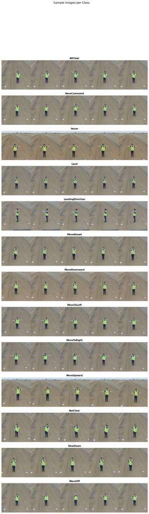

```python
class_samples = {train_dataset.classes[i]: [] for i in range(num_classes)}
for i in range(num_classes):
    while len(class_samples[train_dataset.classes[i]]) < 1:
        for file in os.listdir(f'../conc_dataset/train/{train_dataset.classes[i]}/'):
            if fnmatch.fnmatch(file, 'S1_Instance1.png'):
                img_path = f'../conc_dataset/train/{train_dataset.classes[i]}/{file}'
                img = Image.open(img_path)
                class_samples[train_dataset.classes[i]].append(img)

# Show sample images from each class
fig, axes = plt.subplots(13, 1, figsize=(16, 40))
fig.suptitle('Sample Images per Class', fontsize=14)

for col in range(len(class_samples)):
    axes[col].imshow(class_samples[train_dataset.classes[col]][0])
    axes[col].axis('off')
    axes[col].set_title(class_name_list[col], fontsize=11, fontweight='bold')
```

Observations:

- direction seems to be an important quality to some of these gestures (e.g. MoveLeft and MoveRight)

Decision:

- augmentation should exclude random flipping to lose directionality of the gestures
- excessive rotation should be avoided during augmentation, given the width of the tensors could make them susceptible to the appearance of larger black borders, or the exclusion of edge frames.
- random cropping should be avoided, to ensure all key frames remain present in the sample

Setting Up Transforms with Augmentations:

```python
# ImageNet normalisation (required for pretrained models)
IMAGENET_MEAN = [0.485, 0.456, 0.406]
IMAGENET_STD = [0.229, 0.224, 0.225]

train_transform_v1 = transforms.Compose([
    transforms.Resize((IMG_HEIGHT, IMG_WIDTH)),
    transforms.ColorJitter(brightness=0.2, contrast=0.2, saturation=0.2),
    transforms.RandomGrayscale(),
    transforms.ToTensor(),
    transforms.Normalize(IMAGENET_MEAN, IMAGENET_STD),
])

val_transform = transforms.Compose([
    transforms.Resize((IMG_HEIGHT, IMG_WIDTH)),
    transforms.ToTensor(),
    transforms.Normalize(IMAGENET_MEAN, IMAGENET_STD)
])

train_ds_v1 = datasets.ImageFolder(train_dir, transform=train_transform_v1)
val_ds = datasets.ImageFolder(val_dir, transform=val_transform)

train_loader_v1 = DataLoader(train_ds_v1, batch_size=16, shuffle=True, num_workers=2, pin_memory=True)
val_loader = DataLoader(val_ds, batch_size=32, shuffle=False, num_workers=2, pin_memory=True)
```

Evaluating ResNet-18:

```python
resnet18 = resnet18(weights=ResNet18_Weights.IMAGENET1K_V1)
print(resnet18)
```

```
Downloading: "https://download.pytorch.org/models/resnet18-f37072fd.pth" to /home/ec2-user/.cache/torch/hub/checkpoints/resnet18-f37072fd.pth
```

```
ResNet(
  (conv1): Conv2d(3, 64, kernel_size=(7, 7), stride=(2, 2), padding=(3, 3), bias=False)
  (bn1): BatchNorm2d(64, eps=1e-05, momentum=0.1, affine=True, track_running_stats=True)
  (relu): ReLU(inplace=True)
  (maxpool): MaxPool2d(kernel_size=3, stride=2, padding=1, dilation=1, ceil_mode=False)
  (layer1): Sequential(
    (0): BasicBlock(
      (conv1): Conv2d(64, 64, kernel_size=(3, 3), stride=(1, 1), padding=(1, 1), bias=False)
      (bn1): BatchNorm2d(64, eps=1e-05, momentum=0.1, affine=True, track_running_stats=True)
      (relu): ReLU(inplace=True)
      (conv2): Conv2d(64, 64, kernel_size=(3, 3), stride=(1, 1), padding=(1, 1), bias=False)
      (bn2): BatchNorm2d(64, eps=1e-05, momentum=0.1, affine=True, track_running_stats=True)
    )
    (1): BasicBlock(
      (conv1): Conv2d(64, 64, kernel_size=(3, 3), stride=(1, 1), padding=(1, 1), bias=False)
      (bn1): BatchNorm2d(64, eps=1e-05, momentum=0.1, affine=True, track_running_stats=True)
      (relu): ReLU(inplace=True)
      (conv2): Conv2d(64, 64, kernel_size=(3, 3), stride=(1, 1), padding=(1, 1), bias=False)
      (bn2): BatchNorm2d(64, eps=1e-05, momentum=0.1, affine=True, track_running_stats=True)
    )
  )
  (layer2): Sequential(
    (0): BasicBlock(
      (conv1): Conv2d(64, 128, kernel_size=(3, 3), stride=(2, 2), padding=(1, 1), bias=False)
      (bn1): BatchNorm2d(128, eps=1e-05, momentum=0.1, affine=True, track_running_stats=True)
      (relu): ReLU(inplace=True)
      (conv2): Conv2d(128, 128, kernel_size=(3, 3), stride=(1, 1), padding=(1, 1), bias=False)
      (bn2): BatchNorm2d(128, eps=1e-05, momentum=0.1, affine=True, track_running_stats=True)
      (downsample): Sequential(
        (0): Conv2d(64, 128, kernel_size=(1, 1), stride=(2, 2), bias=False)
        (1): BatchNorm2d(128, eps=1e-05, momentum=0.1, affine=True, track_running_stats=True)
      )
    )
    (1): BasicBlock(
      (conv1): Conv2d(128, 128, kernel_size=(3, 3), stride=(1, 1), padding=(1, 1), bias=False)
      (bn1): BatchNorm2d(128, eps=1e-05, momentum=0.1, affine=True, track_running_stats=True)
      (relu): ReLU(inplace=True)
      (conv2): Conv2d(128, 128, kernel_size=(3, 3), stride=(1, 1), padding=(1, 1), bias=False)
      (bn2): BatchNorm2d(128, eps=1e-05, momentum=0.1, affine=True, track_running_stats=True)
    )
```

[output cut: 29 more lines]

```
        (0): Conv2d(256, 512, kernel_size=(1, 1), stride=(2, 2), bias=False)
        (1): BatchNorm2d(512, eps=1e-05, momentum=0.1, affine=True, track_running_stats=True)
      )
    )
    (1): BasicBlock(
      (conv1): Conv2d(512, 512, kernel_size=(3, 3), stride=(1, 1), padding=(1, 1), bias=False)
      (bn1): BatchNorm2d(512, eps=1e-05, momentum=0.1, affine=True, track_running_stats=True)
      (relu): ReLU(inplace=True)
      (conv2): Conv2d(512, 512, kernel_size=(3, 3), stride=(1, 1), padding=(1, 1), bias=False)
      (bn2): BatchNorm2d(512, eps=1e-05, momentum=0.1, affine=True, track_running_stats=True)
    )
  )
  (avgpool): AdaptiveAvgPool2d(output_size=(1, 1))
  (fc): Linear(in_features=512, out_features=1000, bias=True)
)
```

Reimport ResNet-18 (so that weights can be reassigned in later transfer-learning function):

```python
from torchvision.models import resnet18, ResNet18_Weights
```

Observation:

- the second last layer (avgpool) performs Adaptive Average Pooling. This enables the network to take images of varying dimensions, such as my transformed tensors.
- the final layer (fc) is a fully connected layer that outputs for resnet18's 1000 classes.

Decision:

- tensors do not need to be resized into squares of specified dimensions, as the resnet18 backbone will perform Adaptive Average Pooling.
- the (fc) layer needs to be replaced with a new classification head, trained upon the 13 gesture classes in our scenario.

Baseline - Linear Probing Transfer Learning with ResNet-18 Backbone:

```python
def create_resnet18(dropout=0.0, num_classes=13):
    model = resnet18(weights=ResNet18_Weights.IMAGENET1K_V1)
    model.fc = nn.Sequential(
        nn.Dropout(dropout),
        nn.Linear(model.fc.in_features, num_classes)
    )
    return model

def freeze_backbone(model):
    for name, param in model.named_parameters():
        if 'fc' not in name:
            param.requires_grad = False

def unfreeze_backbone(model):
    for param in model.parameters():
        param.requires_grad = True

def count_params(model):
    trainable = sum(p.numel() for p in model.parameters() if p.requires_grad)
    total = sum(p.numel() for p in model.parameters())
    print(f'Trainable: {trainable:,} / {total:,} ({trainable/total*100:.2f}%)')
```

Training Utilities:

```python
def plotter(history_hold, metric='loss', ylim=None):
    cycol = cycle('bgrcmk')
    for name, hist in history_hold.items():
        y_train = hist[metric]
        y_val   = hist['val_' + metric]
        x = np.arange(len(y_val))
        c = next(cycol)
        plt.plot(x, y_train, c + '-',  label=name + '_train')
        plt.plot(x, y_val,   c + '--', label=name + '_val')
    plt.legend()
    plt.xlim([1, max(plt.xlim())])
    if ylim is not None:
        plt.ylim(ylim)
    plt.xlabel('Epoch')
    plt.ylabel(metric)
    plt.grid(True)

m_histories = {}
```

```python
def run_epoch(model, loader, criterion, optimizer=None):
    training = optimizer is not None
    model.train(training)

    if training:
        # Keep frozen BatchNorm layers fixed during linear probing
        for module in model.modules():
            if isinstance(module, nn.BatchNorm2d):
                if not any(p.requires_grad for p in module.parameters()):
                    module.eval()

    total_loss, ys, preds = 0.0, [], []
    ctx = torch.enable_grad() if training else torch.no_grad()

    with ctx:
        for xb, yb in loader:
            xb, yb = xb.to(device), yb.to(device)

            logits = model(xb)
            loss = criterion(logits, yb)

            if training:
                optimizer.zero_grad()
                loss.backward()
                optimizer.step()

            total_loss += loss.item() * len(xb)
            ys.extend(yb.cpu().numpy())
            preds.extend(logits.argmax(1).detach().cpu().numpy())

    n = len(ys)
    class_labels = list(range(num_classes))

    metrics = {
        'loss':      total_loss / n,
        'accuracy':  accuracy_score(ys, preds),
        'precision': precision_score(
            ys, preds,
            labels=class_labels,
            average='macro',
            zero_division=0
        ),
        'recall':    recall_score(
            ys, preds,
            labels=class_labels,
            average='macro',
            zero_division=0
        ),
        'f1-score':  f1_score(
            ys, preds,
            labels=class_labels,
            average='macro',
            zero_division=0
        ),
    }
    return metrics
```

Calculating Weights for Weighted Cross Entropy Loss:

```python
train_labels = train_dataset.targets
class_counts = np.bincount(train_labels)
num_samples = len(train_labels)

class_weights = num_samples / (num_classes * class_counts)

class_weights = torch.tensor(
    class_weights,
    dtype=torch.float32,
    device=device
)
```

```python
def train_and_track(model, train_loader, val_loader, epochs=10, lr=1e-3,
                    optimizer=None, verbose=True):
    model = model.to(device)
    if optimizer is None:
        optimizer = torch.optim.Adam(
            filter(lambda p: p.requires_grad, model.parameters()), lr=lr)
    # Applying class weights only to training set loss calculation
    train_criterion = nn.CrossEntropyLoss(weight=class_weights)
    val_criterion = nn.CrossEntropyLoss()

    hist = {k: [] for k in ['loss', 'accuracy', 'precision', 'recall', 'f1-score',
                                'val_loss', 'val_accuracy', 'val_precision',
                                'val_recall', 'val_f1-score']}
    for ep in range(epochs):
        tr = run_epoch(model, train_loader, train_criterion, optimizer=optimizer)
        vl = run_epoch(model, val_loader,   val_criterion, optimizer=None)
        for k, v in tr.items(): hist[k].append(v)
        for k, v in vl.items(): hist['val_' + k].append(v)
        if verbose:
            print(f'ep {ep+1:2d}/{epochs} '
                    f'loss {tr["loss"]:.3f} acc {tr["accuracy"]:.3f}  | '
                    f'val_loss {vl["loss"]:.3f} val_acc {vl["accuracy"]:.3f}  '
                    f'val_prec {vl["precision"]:.3f}  val_rec {vl["recall"]:.3f}  val_f1-score {vl["f1-score"]:.3f}')
    return hist
```

Train Baseline Model:

```python
epochs = 10

torch.manual_seed(42)

if torch.cuda.is_available():
    torch.cuda.manual_seed_all(42)

baseline_model = create_resnet18(dropout=0.0, num_classes=num_classes).to(device)
freeze_backbone(baseline_model)

print("Fresh linear-probing baseline")
count_params(baseline_model)

m_histories['baseline: linear probing'] = train_and_track(baseline_model, train_loader_v1, val_loader, epochs=epochs, lr=1e-3)
```

```
Fresh linear-probing baseline
Trainable: 6,669 / 11,183,181 (0.06%)
ep  1/10 loss 2.463 acc 0.140  | val_loss 2.451 val_acc 0.120  val_prec 0.082  val_rec 0.080  val_f1-score 0.058
ep  2/10 loss 2.091 acc 0.282  | val_loss 2.002 val_acc 0.340  val_prec 0.128  val_rec 0.173  val_f1-score 0.108
ep  3/10 loss 1.844 acc 0.377  | val_loss 1.941 val_acc 0.390  val_prec 0.196  val_rec 0.224  val_f1-score 0.175
ep  4/10 loss 1.679 acc 0.443  | val_loss 1.946 val_acc 0.390  val_prec 0.097  val_rec 0.231  val_f1-score 0.129
ep  5/10 loss 1.557 acc 0.485  | val_loss 1.799 val_acc 0.430  val_prec 0.199  val_rec 0.310  val_f1-score 0.239
ep  6/10 loss 1.446 acc 0.546  | val_loss 1.861 val_acc 0.390  val_prec 0.147  val_rec 0.239  val_f1-score 0.165
ep  7/10 loss 1.347 acc 0.561  | val_loss 1.783 val_acc 0.410  val_prec 0.167  val_rec 0.269  val_f1-score 0.179
ep  8/10 loss 1.303 acc 0.585  | val_loss 1.679 val_acc 0.380  val_prec 0.207  val_rec 0.223  val_f1-score 0.176
ep  9/10 loss 1.202 acc 0.634  | val_loss 1.700 val_acc 0.370  val_prec 0.227  val_rec 0.212  val_f1-score 0.190
ep 10/10 loss 1.126 acc 0.693  | val_loss 1.695 val_acc 0.460  val_prec 0.223  val_rec 0.314  val_f1-score 0.217
```

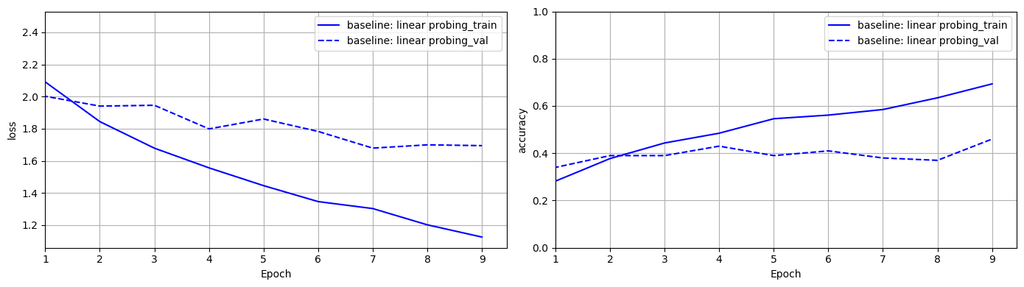

```python
fig, axes = plt.subplots(1, 2, figsize=(14, 4))
plt.sca(axes[0]); plotter(m_histories, metric='loss')
plt.sca(axes[1]); plotter(m_histories, metric='accuracy', ylim=[0.0, 1.0])
plt.tight_layout(); plt.show()
```

Observation:

- training loss decreases while validation loss plateus and slightly rises, creating a validation gap, showing overfitting
- Macro F1-Score finished at 0.217, far below intended goal, which is a consequence of overfitting.

Hypothesis:

- resnet-18 backbone is trained on the ImageNet dataset, which is mostly square images with one subject present. This contrasts from our concatenated images with five subjects appearing. Perhaps the existing weights of the backbone are poorly adapted for this scenario.

Decision:

- unfreeze backbone and attempt fine tuning

```python
torch.manual_seed(42)

if torch.cuda.is_available():
    torch.cuda.manual_seed_all(42)

epochs = 3
model_ft = create_resnet18(dropout=0.0, num_classes=num_classes).to(device)
freeze_backbone(model_ft)

print("training model head")
count_params(model_ft)

m_histories['model head training'] = train_and_track(model_ft, train_loader_v1, val_loader, epochs=epochs, lr=1e-3)

epochs = 10
unfreeze_backbone(model_ft)

print("fine-tuning model")
count_params(model_ft)

m_histories['fine-tuning model'] = train_and_track(model_ft, train_loader_v1, val_loader, epochs=epochs, lr=1e-5)
```

```
training model head
Trainable: 6,669 / 11,183,181 (0.06%)
ep  1/3 loss 2.463 acc 0.140  | val_loss 2.451 val_acc 0.120  val_prec 0.082  val_rec 0.080  val_f1-score 0.058
ep  2/3 loss 2.091 acc 0.282  | val_loss 2.002 val_acc 0.340  val_prec 0.128  val_rec 0.173  val_f1-score 0.108
ep  3/3 loss 1.844 acc 0.377  | val_loss 1.941 val_acc 0.390  val_prec 0.196  val_rec 0.224  val_f1-score 0.175
fine-tuning model
Trainable: 11,183,181 / 11,183,181 (100.00%)
ep  1/10 loss 1.836 acc 0.340  | val_loss 1.720 val_acc 0.450  val_prec 0.247  val_rec 0.365  val_f1-score 0.266
ep  2/10 loss 1.297 acc 0.587  | val_loss 1.563 val_acc 0.560  val_prec 0.330  val_rec 0.477  val_f1-score 0.373
ep  3/10 loss 1.065 acc 0.741  | val_loss 1.475 val_acc 0.590  val_prec 0.444  val_rec 0.528  val_f1-score 0.426
ep  4/10 loss 0.848 acc 0.866  | val_loss 1.412 val_acc 0.600  val_prec 0.473  val_rec 0.524  val_f1-score 0.438
ep  5/10 loss 0.732 acc 0.886  | val_loss 1.321 val_acc 0.640  val_prec 0.671  val_rec 0.565  val_f1-score 0.517
ep  6/10 loss 0.584 acc 0.927  | val_loss 1.297 val_acc 0.600  val_prec 0.571  val_rec 0.530  val_f1-score 0.468
ep  7/10 loss 0.491 acc 0.941  | val_loss 1.232 val_acc 0.630  val_prec 0.622  val_rec 0.562  val_f1-score 0.513
ep  8/10 loss 0.402 acc 0.962  | val_loss 1.199 val_acc 0.620  val_prec 0.545  val_rec 0.560  val_f1-score 0.484
ep  9/10 loss 0.354 acc 0.978  | val_loss 1.145 val_acc 0.660  val_prec 0.613  val_rec 0.601  val_f1-score 0.544
ep 10/10 loss 0.314 acc 0.962  | val_loss 1.132 val_acc 0.650  val_prec 0.551  val_rec 0.590  val_f1-score 0.520
```

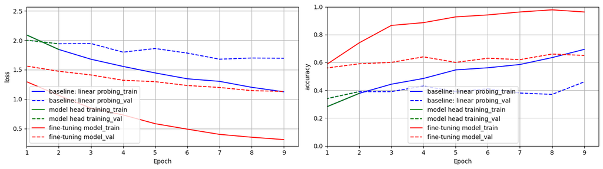

```python
fig, axes = plt.subplots(1, 2, figsize=(14, 4))
plt.sca(axes[0]); plotter(m_histories, metric='loss')
plt.sca(axes[1]); plotter(m_histories, metric='accuracy', ylim=[0.0, 1.0])
plt.tight_layout(); plt.show()
```

Observation:

- fine-tuning model's train/val loss are respectively lower than the baseline models'
- train/val accuracy are also respectively higher
- Macro F1-Score finished at 0.520, which is a significant improvement, but remains below target
- validation gap still occurred, showing overfitting.

Hypothesis:

- fine-tuning has improved performance, likely due to resnet-18's backbone parameters adjusting to the provided dataset.
- training dataset remains too easily memorised for the fine-tuning model, resulting in overfitting.

Decision:

- retain usage of fine-tuning, as Macro F1-Score and other metrics improved.
- apply Drop-Out as a regularisation method, to increase training difficulty for the fine-tuning model, to attempt mitigating overfitting

```python
m_histories_2 = {}
m_histories_2['baseline: linear probing'] = m_histories['baseline: linear probing']
m_histories_2['fine-tuning model'] = m_histories['fine-tuning model']

torch.manual_seed(42)

if torch.cuda.is_available():
    torch.cuda.manual_seed_all(42)

epochs = 3
model_ft = create_resnet18(dropout=0.1, num_classes=num_classes).to(device)
freeze_backbone(model_ft)

print("training model head")
count_params(model_ft)

m_histories_2['dropout model head training'] = train_and_track(model_ft, train_loader_v1, val_loader, epochs=epochs, lr=1e-3)

epochs = 10
unfreeze_backbone(model_ft)

print("fine-tuning model")
count_params(model_ft)

m_histories_2['fine-tuning model with dropout'] = train_and_track(model_ft, train_loader_v1, val_loader, epochs=epochs, lr=1e-5)
```

```
training model head
Trainable: 6,669 / 11,183,181 (0.06%)
ep  1/3 loss 2.498 acc 0.138  | val_loss 2.452 val_acc 0.120  val_prec 0.081  val_rec 0.080  val_f1-score 0.057
ep  2/3 loss 2.135 acc 0.269  | val_loss 2.015 val_acc 0.350  val_prec 0.129  val_rec 0.192  val_f1-score 0.129
ep  3/3 loss 1.886 acc 0.388  | val_loss 1.972 val_acc 0.390  val_prec 0.135  val_rec 0.220  val_f1-score 0.162
fine-tuning model
Trainable: 11,183,181 / 11,183,181 (100.00%)
ep  1/10 loss 1.912 acc 0.327  | val_loss 1.773 val_acc 0.450  val_prec 0.249  val_rec 0.365  val_f1-score 0.266
ep  2/10 loss 1.356 acc 0.542  | val_loss 1.601 val_acc 0.530  val_prec 0.321  val_rec 0.432  val_f1-score 0.339
ep  3/10 loss 1.112 acc 0.679  | val_loss 1.501 val_acc 0.590  val_prec 0.434  val_rec 0.509  val_f1-score 0.423
ep  4/10 loss 0.910 acc 0.802  | val_loss 1.439 val_acc 0.580  val_prec 0.392  val_rec 0.500  val_f1-score 0.404
ep  5/10 loss 0.797 acc 0.836  | val_loss 1.352 val_acc 0.600  val_prec 0.452  val_rec 0.518  val_f1-score 0.439
ep  6/10 loss 0.629 acc 0.907  | val_loss 1.328 val_acc 0.580  val_prec 0.414  val_rec 0.504  val_f1-score 0.421
ep  7/10 loss 0.538 acc 0.929  | val_loss 1.259 val_acc 0.600  val_prec 0.535  val_rec 0.525  val_f1-score 0.456
ep  8/10 loss 0.446 acc 0.942  | val_loss 1.219 val_acc 0.630  val_prec 0.546  val_rec 0.564  val_f1-score 0.486
ep  9/10 loss 0.393 acc 0.965  | val_loss 1.178 val_acc 0.610  val_prec 0.538  val_rec 0.544  val_f1-score 0.476
ep 10/10 loss 0.346 acc 0.961  | val_loss 1.165 val_acc 0.640  val_prec 0.548  val_rec 0.577  val_f1-score 0.504
```

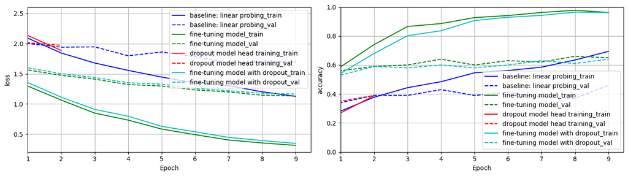

```python
fig, axes = plt.subplots(1, 2, figsize=(14, 4))
plt.sca(axes[0]); plotter(m_histories_2, metric='loss')
plt.sca(axes[1]); plotter(m_histories_2, metric='accuracy', ylim=[0.0, 1.0])
plt.tight_layout(); plt.show()
```

Observation:

- validation gap did not reduce in drop-out model
- loss increased and accuracy decreased in drop-out model
- Macro F1-Score finished at 0.504, a decrease from the prior model that did not use drop-out

Hypothesis:

- continue exploring other levels of dropout before coming to a decision

```python
m_histories_3 = {}
m_histories_3['baseline: linear probing'] = m_histories['baseline: linear probing']
m_histories_3['fine-tuning model with dropout'] = m_histories_2['fine-tuning model with dropout']

torch.manual_seed(42)

if torch.cuda.is_available():
    torch.cuda.manual_seed_all(42)

epochs = 3
model_ft = create_resnet18(dropout=0.2, num_classes=num_classes).to(device)
freeze_backbone(model_ft)

print("training model head")
count_params(model_ft)

m_histories_3['increased dropout model head training'] = train_and_track(model_ft, train_loader_v1, val_loader, epochs=epochs, lr=1e-3)

epochs = 10
unfreeze_backbone(model_ft)

print("fine-tuning model")
count_params(model_ft)

m_histories_3['fine-tuning model with increased dropout'] = train_and_track(model_ft, train_loader_v1, val_loader, epochs=epochs, lr=1e-5)
```

```
training model head
Trainable: 6,669 / 11,183,181 (0.06%)
ep  1/3 loss 2.551 acc 0.118  | val_loss 2.465 val_acc 0.080  val_prec 0.079  val_rec 0.044  val_f1-score 0.048
ep  2/3 loss 2.192 acc 0.241  | val_loss 2.034 val_acc 0.370  val_prec 0.130  val_rec 0.231  val_f1-score 0.156
ep  3/3 loss 1.953 acc 0.338  | val_loss 1.970 val_acc 0.360  val_prec 0.111  val_rec 0.187  val_f1-score 0.138
fine-tuning model
Trainable: 11,183,181 / 11,183,181 (100.00%)
ep  1/10 loss 1.958 acc 0.316  | val_loss 1.765 val_acc 0.470  val_prec 0.247  val_rec 0.375  val_f1-score 0.272
ep  2/10 loss 1.406 acc 0.522  | val_loss 1.602 val_acc 0.510  val_prec 0.313  val_rec 0.417  val_f1-score 0.320
ep  3/10 loss 1.173 acc 0.642  | val_loss 1.510 val_acc 0.570  val_prec 0.409  val_rec 0.483  val_f1-score 0.404
ep  4/10 loss 0.967 acc 0.749  | val_loss 1.450 val_acc 0.570  val_prec 0.394  val_rec 0.487  val_f1-score 0.393
ep  5/10 loss 0.854 acc 0.787  | val_loss 1.360 val_acc 0.620  val_prec 0.418  val_rec 0.538  val_f1-score 0.454
ep  6/10 loss 0.682 acc 0.869  | val_loss 1.334 val_acc 0.620  val_prec 0.506  val_rec 0.541  val_f1-score 0.474
ep  7/10 loss 0.594 acc 0.913  | val_loss 1.277 val_acc 0.620  val_prec 0.572  val_rec 0.547  val_f1-score 0.488
ep  8/10 loss 0.499 acc 0.926  | val_loss 1.232 val_acc 0.630  val_prec 0.547  val_rec 0.564  val_f1-score 0.487
ep  9/10 loss 0.436 acc 0.953  | val_loss 1.193 val_acc 0.610  val_prec 0.538  val_rec 0.544  val_f1-score 0.476
ep 10/10 loss 0.381 acc 0.954  | val_loss 1.180 val_acc 0.630  val_prec 0.542  val_rec 0.562  val_f1-score 0.498
```

```python
m_histories_4 = {}
m_histories_4['fine-tuning model'] = m_histories['fine-tuning model']
m_histories_4['ft w/ 0.1 dropout'] = m_histories_2['fine-tuning model with dropout']
m_histories_4['ft w/ 0.2 dropout'] = m_histories_3['fine-tuning model with increased dropout']

torch.manual_seed(42)

if torch.cuda.is_available():
    torch.cuda.manual_seed_all(42)

epochs = 3
model_ft = create_resnet18(dropout=0.3, num_classes=num_classes).to(device)
freeze_backbone(model_ft)

print("training model head")
count_params(model_ft)

m_histories_4['0.3 dropout head training'] = train_and_track(model_ft, train_loader_v1, val_loader, epochs=epochs, lr=1e-3)

epochs = 10
unfreeze_backbone(model_ft)

print("fine-tuning model")
count_params(model_ft)

m_histories_4['ft w/ 0.3 dropout'] = train_and_track(model_ft, train_loader_v1, val_loader, epochs=epochs, lr=1e-5)
```

```
training model head
Trainable: 6,669 / 11,183,181 (0.06%)
ep  1/3 loss 2.597 acc 0.119  | val_loss 2.462 val_acc 0.110  val_prec 0.082  val_rec 0.076  val_f1-score 0.053
ep  2/3 loss 2.245 acc 0.225  | val_loss 2.052 val_acc 0.370  val_prec 0.131  val_rec 0.231  val_f1-score 0.156
ep  3/3 loss 2.008 acc 0.302  | val_loss 1.979 val_acc 0.340  val_prec 0.093  val_rec 0.169  val_f1-score 0.118
fine-tuning model
Trainable: 11,183,181 / 11,183,181 (100.00%)
ep  1/10 loss 2.022 acc 0.295  | val_loss 1.780 val_acc 0.470  val_prec 0.244  val_rec 0.375  val_f1-score 0.271
ep  2/10 loss 1.480 acc 0.498  | val_loss 1.619 val_acc 0.480  val_prec 0.303  val_rec 0.368  val_f1-score 0.302
ep  3/10 loss 1.250 acc 0.594  | val_loss 1.530 val_acc 0.550  val_prec 0.320  val_rec 0.459  val_f1-score 0.366
ep  4/10 loss 1.037 acc 0.709  | val_loss 1.472 val_acc 0.570  val_prec 0.390  val_rec 0.487  val_f1-score 0.391
ep  5/10 loss 0.932 acc 0.754  | val_loss 1.386 val_acc 0.630  val_prec 0.588  val_rec 0.552  val_f1-score 0.491
ep  6/10 loss 0.744 acc 0.836  | val_loss 1.359 val_acc 0.590  val_prec 0.414  val_rec 0.509  val_f1-score 0.425
ep  7/10 loss 0.669 acc 0.861  | val_loss 1.292 val_acc 0.610  val_prec 0.533  val_rec 0.538  val_f1-score 0.472
ep  8/10 loss 0.570 acc 0.892  | val_loss 1.251 val_acc 0.620  val_prec 0.541  val_rec 0.553  val_f1-score 0.480
ep  9/10 loss 0.490 acc 0.929  | val_loss 1.198 val_acc 0.620  val_prec 0.540  val_rec 0.549  val_f1-score 0.480
ep 10/10 loss 0.434 acc 0.932  | val_loss 1.192 val_acc 0.620  val_prec 0.539  val_rec 0.549  val_f1-score 0.479
```

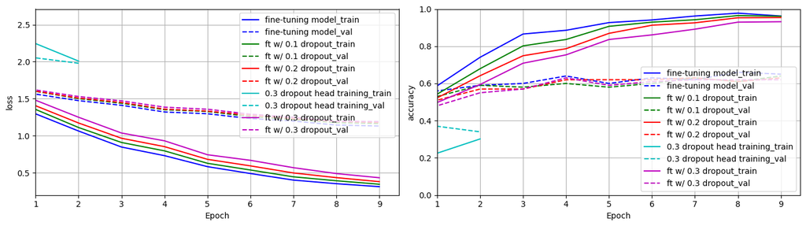

```python
fig, axes = plt.subplots(1, 2, figsize=(14, 4))
plt.sca(axes[0]); plotter(m_histories_4, metric='loss')
plt.sca(axes[1]); plotter(m_histories_4, metric='accuracy', ylim=[0.0, 1.0])
plt.tight_layout(); plt.show()
```

Observation:

- with successive increases of drop-out, final Macro F1-Scores decreased (0.520, 0.504, 0.498, 0.479, for models with dropout set to 0.0, 0.1, 0.2, and 0.3 respectively)

Decision:

- drop-out will be excluded from further iterations upon the model
- will explore strengthening augmentation as a means of reducing overfitting

Stronger Augmentation:

```python
train_transform_v2 = transforms.Compose([
    transforms.Resize((IMG_HEIGHT, IMG_WIDTH)),
    transforms.RandomRotation(15),
    transforms.ColorJitter(brightness=0.2, contrast=0.2, saturation=0.2),
    transforms.RandomAffine(degrees=0, translate=(0.1, 0.1)),
    transforms.RandomGrayscale(),
    transforms.ToTensor(),
    transforms.Normalize(IMAGENET_MEAN, IMAGENET_STD),
])

train_ds_v2 = datasets.ImageFolder(train_dir, transform=train_transform_v2)

train_loader_v2 = DataLoader(train_ds_v2, batch_size=16, shuffle=True, num_workers=2, pin_memory=True)
```

```python
torch.manual_seed(42)

if torch.cuda.is_available():
    torch.cuda.manual_seed_all(42)

epochs = 3
model_ft = create_resnet18(dropout=0.0, num_classes=num_classes).to(device)
freeze_backbone(model_ft)

print("training model head")
count_params(model_ft)

m_histories['stronger aug model head training'] = train_and_track(model_ft, train_loader_v2, val_loader, epochs=epochs, lr=1e-3)

epochs = 10
unfreeze_backbone(model_ft)

print("fine-tuning model")
count_params(model_ft)

m_histories['stronger aug fine-tuning model'] = train_and_track(model_ft, train_loader_v2, val_loader, epochs=epochs, lr=1e-5)
```

```
training model head
Trainable: 6,669 / 11,183,181 (0.06%)
ep  1/3 loss 2.540 acc 0.127  | val_loss 2.475 val_acc 0.150  val_prec 0.082  val_rec 0.118  val_f1-score 0.063
ep  2/3 loss 2.259 acc 0.222  | val_loss 2.068 val_acc 0.340  val_prec 0.090  val_rec 0.173  val_f1-score 0.103
ep  3/3 loss 2.055 acc 0.310  | val_loss 1.977 val_acc 0.350  val_prec 0.126  val_rec 0.185  val_f1-score 0.137
fine-tuning model
Trainable: 11,183,181 / 11,183,181 (100.00%)
ep  1/10 loss 2.016 acc 0.338  | val_loss 1.705 val_acc 0.370  val_prec 0.131  val_rec 0.223  val_f1-score 0.157
ep  2/10 loss 1.638 acc 0.439  | val_loss 1.538 val_acc 0.390  val_prec 0.111  val_rec 0.253  val_f1-score 0.153
ep  3/10 loss 1.416 acc 0.547  | val_loss 1.413 val_acc 0.520  val_prec 0.297  val_rec 0.410  val_f1-score 0.313
ep  4/10 loss 1.229 acc 0.629  | val_loss 1.264 val_acc 0.560  val_prec 0.379  val_rec 0.464  val_f1-score 0.373
ep  5/10 loss 1.096 acc 0.705  | val_loss 1.161 val_acc 0.580  val_prec 0.401  val_rec 0.484  val_f1-score 0.406
ep  6/10 loss 0.970 acc 0.722  | val_loss 1.083 val_acc 0.620  val_prec 0.492  val_rec 0.531  val_f1-score 0.464
ep  7/10 loss 0.836 acc 0.821  | val_loss 1.003 val_acc 0.620  val_prec 0.500  val_rec 0.535  val_f1-score 0.470
ep  8/10 loss 0.751 acc 0.825  | val_loss 0.875 val_acc 0.730  val_prec 0.570  val_rec 0.661  val_f1-score 0.600
ep  9/10 loss 0.673 acc 0.866  | val_loss 0.843 val_acc 0.690  val_prec 0.560  val_rec 0.614  val_f1-score 0.567
ep 10/10 loss 0.617 acc 0.869  | val_loss 0.804 val_acc 0.740  val_prec 0.573  val_rec 0.674  val_f1-score 0.608
```

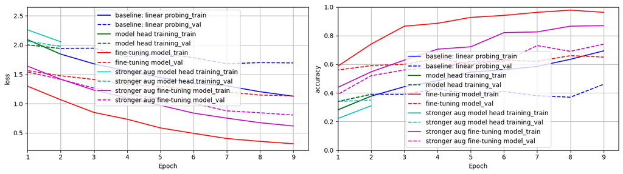

```python
fig, axes = plt.subplots(1, 2, figsize=(14, 4))
plt.sca(axes[0]); plotter(m_histories, metric='loss')
plt.sca(axes[1]); plotter(m_histories, metric='accuracy', ylim=[0.0, 1.0])
plt.tight_layout(); plt.show()
```

Observation:

Decision:

- Train this model for a further 10 epochs to see if overfitting or if convergence is delayed

```python
m_histories_5 = {}
m_histories_5['fine-tuning model'] = m_histories['fine-tuning model']
m_histories_5['stronger aug fine-tuning model'] = m_histories['stronger aug fine-tuning model']
m_histories_5['further training of stronger aug model'] = train_and_track(model_ft, train_loader_v2, val_loader, epochs=epochs, lr=1e-5)
```

```
ep  1/10 loss 0.557 acc 0.884  | val_loss 0.737 val_acc 0.780  val_prec 0.622  val_rec 0.716  val_f1-score 0.657
ep  2/10 loss 0.481 acc 0.913  | val_loss 0.723 val_acc 0.760  val_prec 0.581  val_rec 0.699  val_f1-score 0.626
ep  3/10 loss 0.414 acc 0.940  | val_loss 0.716 val_acc 0.760  val_prec 0.584  val_rec 0.699  val_f1-score 0.625
ep  4/10 loss 0.411 acc 0.927  | val_loss 0.671 val_acc 0.750  val_prec 0.591  val_rec 0.688  val_f1-score 0.623
ep  5/10 loss 0.340 acc 0.936  | val_loss 0.628 val_acc 0.770  val_prec 0.688  val_rec 0.714  val_f1-score 0.665
ep  6/10 loss 0.303 acc 0.958  | val_loss 0.702 val_acc 0.760  val_prec 0.586  val_rec 0.699  val_f1-score 0.628
ep  7/10 loss 0.281 acc 0.954  | val_loss 0.713 val_acc 0.760  val_prec 0.587  val_rec 0.699  val_f1-score 0.628
ep  8/10 loss 0.248 acc 0.955  | val_loss 0.741 val_acc 0.750  val_prec 0.599  val_rec 0.684  val_f1-score 0.629
ep  9/10 loss 0.226 acc 0.965  | val_loss 0.712 val_acc 0.780  val_prec 0.681  val_rec 0.730  val_f1-score 0.683
ep 10/10 loss 0.193 acc 0.978  | val_loss 0.819 val_acc 0.750  val_prec 0.587  val_rec 0.688  val_f1-score 0.622
```

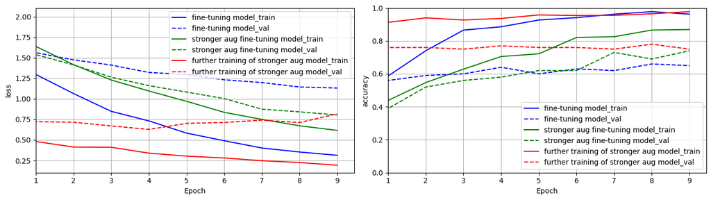

```python
fig, axes = plt.subplots(1, 2, figsize=(14, 4))
plt.sca(axes[0]); plotter(m_histories_5, metric='loss')
plt.sca(axes[1]); plotter(m_histories_5, metric='accuracy', ylim=[0.0, 1.0])
plt.tight_layout(); plt.show()
```

Note: "further training of stronger aug model" continues from the end-point of "stronger aug fine-tuning model"

Observation:

Decision:

- the persistence and growth of the validation gap indicates an overfitting model
- keep stronger augmenations to maintain increase in Macro F1-Score
- apply L2 Regularisation with AdamW optimization (By design, AdamW utilises weight decay in a more similar manner to L2 Regularisation than standard Adam optimization)

```python
m_histories_6 = {}
m_histories_6['fine-tuning'] = m_histories['fine-tuning model']
m_histories_6['stronger-aug'] = m_histories_5['stronger aug fine-tuning model']

torch.manual_seed(42)

if torch.cuda.is_available():
    torch.cuda.manual_seed_all(42)

epochs = 3
model_ft = create_resnet18(dropout=0.0, num_classes=num_classes).to(device)
freeze_backbone(model_ft)

print("training model head")
count_params(model_ft)

optimizer = torch.optim.AdamW(
            filter(lambda p: p.requires_grad, model_ft.parameters()), lr=1e-3, weight_decay=1e-4)

m_histories_6['Weight Decay Head'] = train_and_track(model_ft, train_loader_v2, val_loader, epochs=epochs, lr=1e-3, optimizer=optimizer)

epochs = 10
unfreeze_backbone(model_ft)

print("fine-tuning model")
count_params(model_ft)

optimizer = torch.optim.AdamW(
            filter(lambda p: p.requires_grad, model_ft.parameters()), lr=1e-5, weight_decay=1e-4)

m_histories_6['stronger aug plus weight decay'] = train_and_track(model_ft, train_loader_v2, val_loader, epochs=epochs, lr=1e-5, optimizer=optimizer)
```

```
training model head
Trainable: 6,669 / 11,183,181 (0.06%)
ep  1/3 loss 2.540 acc 0.127  | val_loss 2.475 val_acc 0.150  val_prec 0.082  val_rec 0.118  val_f1-score 0.063
ep  2/3 loss 2.259 acc 0.222  | val_loss 2.068 val_acc 0.340  val_prec 0.090  val_rec 0.173  val_f1-score 0.103
ep  3/3 loss 2.055 acc 0.310  | val_loss 1.977 val_acc 0.350  val_prec 0.126  val_rec 0.185  val_f1-score 0.137
fine-tuning model
Trainable: 11,183,181 / 11,183,181 (100.00%)
ep  1/10 loss 2.016 acc 0.338  | val_loss 1.706 val_acc 0.370  val_prec 0.131  val_rec 0.223  val_f1-score 0.157
ep  2/10 loss 1.638 acc 0.440  | val_loss 1.538 val_acc 0.390  val_prec 0.111  val_rec 0.253  val_f1-score 0.153
ep  3/10 loss 1.417 acc 0.546  | val_loss 1.414 val_acc 0.520  val_prec 0.297  val_rec 0.410  val_f1-score 0.313
ep  4/10 loss 1.230 acc 0.627  | val_loss 1.265 val_acc 0.560  val_prec 0.379  val_rec 0.464  val_f1-score 0.373
ep  5/10 loss 1.096 acc 0.705  | val_loss 1.162 val_acc 0.580  val_prec 0.401  val_rec 0.484  val_f1-score 0.406
ep  6/10 loss 0.970 acc 0.719  | val_loss 1.084 val_acc 0.620  val_prec 0.492  val_rec 0.531  val_f1-score 0.464
ep  7/10 loss 0.836 acc 0.820  | val_loss 1.005 val_acc 0.630  val_prec 0.503  val_rec 0.547  val_f1-score 0.483
ep  8/10 loss 0.751 acc 0.827  | val_loss 0.878 val_acc 0.720  val_prec 0.554  val_rec 0.650  val_f1-score 0.586
ep  9/10 loss 0.673 acc 0.867  | val_loss 0.845 val_acc 0.700  val_prec 0.572  val_rec 0.630  val_f1-score 0.581
ep 10/10 loss 0.617 acc 0.869  | val_loss 0.805 val_acc 0.740  val_prec 0.573  val_rec 0.674  val_f1-score 0.608
```

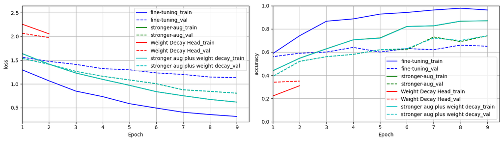

```python
fig, axes = plt.subplots(1, 2, figsize=(14, 4))
plt.sca(axes[0]); plotter(m_histories_6, metric='loss')
plt.sca(axes[1]); plotter(m_histories_6, metric='accuracy', ylim=[0.0, 1.0])
plt.tight_layout(); plt.show()
```

Observation:

- Weight decay of 1e-4 with AdamW optimization produced nearly identical results to the prior model without weight decay.
- considering the operation of AdamW optimization, the applied loss update during fine-tuning was likely 1−(1e-5 × 1e-4) = 1−1e-9 = 0.999999999. This tiny per-step difference is likely why class predictions were unaffected over the course of training.

Decision:

- Try increasing weight decay to 1e-2

```python
torch.manual_seed(42)

if torch.cuda.is_available():
    torch.cuda.manual_seed_all(42)

epochs = 3
model_ft = create_resnet18(dropout=0.0, num_classes=num_classes).to(device)
freeze_backbone(model_ft)

print("training model head")
count_params(model_ft)

optimizer = torch.optim.AdamW(
            filter(lambda p: p.requires_grad, model_ft.parameters()), lr=1e-3, weight_decay=1e-2)

m_histories_6['Stronger Weight Decay Head'] = train_and_track(model_ft, train_loader_v2, val_loader, epochs=epochs, lr=1e-3, optimizer=optimizer)

epochs = 10
unfreeze_backbone(model_ft)

print("fine-tuning model")
count_params(model_ft)

optimizer = torch.optim.AdamW(
            filter(lambda p: p.requires_grad, model_ft.parameters()), lr=1e-5, weight_decay=1e-2)

m_histories_6['Stronger Weight Decay Model'] = train_and_track(model_ft, train_loader_v2, val_loader, epochs=epochs, lr=1e-5, optimizer=optimizer)
```

```
training model head
Trainable: 6,669 / 11,183,181 (0.06%)
ep  1/3 loss 2.540 acc 0.127  | val_loss 2.475 val_acc 0.150  val_prec 0.082  val_rec 0.118  val_f1-score 0.063
ep  2/3 loss 2.259 acc 0.222  | val_loss 2.068 val_acc 0.340  val_prec 0.090  val_rec 0.173  val_f1-score 0.103
ep  3/3 loss 2.056 acc 0.310  | val_loss 1.977 val_acc 0.350  val_prec 0.126  val_rec 0.185  val_f1-score 0.137
fine-tuning model
Trainable: 11,183,181 / 11,183,181 (100.00%)
ep  1/10 loss 2.016 acc 0.338  | val_loss 1.706 val_acc 0.370  val_prec 0.131  val_rec 0.223  val_f1-score 0.157
ep  2/10 loss 1.639 acc 0.440  | val_loss 1.539 val_acc 0.390  val_prec 0.111  val_rec 0.253  val_f1-score 0.153
ep  3/10 loss 1.417 acc 0.547  | val_loss 1.413 val_acc 0.520  val_prec 0.297  val_rec 0.410  val_f1-score 0.313
ep  4/10 loss 1.230 acc 0.629  | val_loss 1.264 val_acc 0.560  val_prec 0.379  val_rec 0.464  val_f1-score 0.373
ep  5/10 loss 1.097 acc 0.705  | val_loss 1.161 val_acc 0.580  val_prec 0.401  val_rec 0.484  val_f1-score 0.406
ep  6/10 loss 0.971 acc 0.722  | val_loss 1.084 val_acc 0.620  val_prec 0.492  val_rec 0.531  val_f1-score 0.464
ep  7/10 loss 0.837 acc 0.820  | val_loss 1.005 val_acc 0.620  val_prec 0.500  val_rec 0.535  val_f1-score 0.470
ep  8/10 loss 0.751 acc 0.825  | val_loss 0.877 val_acc 0.720  val_prec 0.554  val_rec 0.650  val_f1-score 0.586
ep  9/10 loss 0.673 acc 0.864  | val_loss 0.845 val_acc 0.690  val_prec 0.560  val_rec 0.614  val_f1-score 0.567
ep 10/10 loss 0.617 acc 0.868  | val_loss 0.804 val_acc 0.740  val_prec 0.573  val_rec 0.674  val_f1-score 0.608
```

[figure not shown]

```python
fig, axes = plt.subplots(1, 2, figsize=(14, 4))
plt.sca(axes[0]); plotter(m_histories_6, metric='loss')
plt.sca(axes[1]); plotter(m_histories_6, metric='accuracy', ylim=[0.0, 1.0])
plt.tight_layout(); plt.show()
```

Observation:

Decision:

- attempt aggressive weight decay (1) for longer fine-tuning training (20 epochs)

```python
torch.manual_seed(42)

if torch.cuda.is_available():
    torch.cuda.manual_seed_all(42)

epochs = 3
model_ft = create_resnet18(dropout=0.0, num_classes=num_classes).to(device)
freeze_backbone(model_ft)

print("training model head")
count_params(model_ft)

weight_decay = 1

optimizer = torch.optim.AdamW(
            filter(lambda p: p.requires_grad, model_ft.parameters()), lr=1e-3, weight_decay=weight_decay)

m_histories_6['Aggro WD Head'] = train_and_track(model_ft, train_loader_v2, val_loader, epochs=epochs, lr=1e-3, optimizer=optimizer)

epochs = 20
unfreeze_backbone(model_ft)

print("fine-tuning model")
count_params(model_ft)

optimizer = torch.optim.AdamW(
            filter(lambda p: p.requires_grad, model_ft.parameters()), lr=1e-5, weight_decay=weight_decay)

m_histories_6['Aggressive Weight Decay Model'] = train_and_track(model_ft, train_loader_v2, val_loader, epochs=epochs, lr=1e-5, optimizer=optimizer)
```

```
training model head
Trainable: 6,669 / 11,183,181 (0.06%)
ep  1/3 loss 2.496 acc 0.137  | val_loss 2.391 val_acc 0.152  val_prec 0.090  val_rec 0.130  val_f1-score 0.070
ep  2/3 loss 2.237 acc 0.228  | val_loss 2.114 val_acc 0.333  val_prec 0.065  val_rec 0.154  val_f1-score 0.088
ep  3/3 loss 2.096 acc 0.303  | val_loss 1.992 val_acc 0.333  val_prec 0.074  val_rec 0.154  val_f1-score 0.098
fine-tuning model
Trainable: 11,183,181 / 11,183,181 (100.00%)
ep  1/20 loss 1.992 acc 0.293  | val_loss 1.677 val_acc 0.343  val_prec 0.074  val_rec 0.173  val_f1-score 0.103
ep  2/20 loss 1.623 acc 0.479  | val_loss 1.488 val_acc 0.434  val_prec 0.268  val_rec 0.306  val_f1-score 0.232
ep  3/20 loss 1.392 acc 0.553  | val_loss 1.351 val_acc 0.505  val_prec 0.283  val_rec 0.392  val_f1-score 0.307
ep  4/20 loss 1.226 acc 0.628  | val_loss 1.203 val_acc 0.566  val_prec 0.348  val_rec 0.464  val_f1-score 0.380
ep  5/20 loss 1.127 acc 0.684  | val_loss 1.119 val_acc 0.566  val_prec 0.383  val_rec 0.464  val_f1-score 0.381
ep  6/20 loss 0.994 acc 0.746  | val_loss 1.026 val_acc 0.606  val_prec 0.441  val_rec 0.518  val_f1-score 0.441
ep  7/20 loss 0.894 acc 0.773  | val_loss 0.952 val_acc 0.677  val_prec 0.552  val_rec 0.610  val_f1-score 0.533
ep  8/20 loss 0.795 acc 0.823  | val_loss 0.923 val_acc 0.687  val_prec 0.503  val_rec 0.626  val_f1-score 0.546
ep  9/20 loss 0.723 acc 0.856  | val_loss 0.845 val_acc 0.727  val_prec 0.596  val_rec 0.667  val_f1-score 0.602
ep 10/20 loss 0.681 acc 0.878  | val_loss 0.852 val_acc 0.707  val_prec 0.590  val_rec 0.639  val_f1-score 0.589
ep 11/20 loss 0.585 acc 0.903  | val_loss 0.816 val_acc 0.737  val_prec 0.590  val_rec 0.674  val_f1-score 0.614
ep 12/20 loss 0.530 acc 0.904  | val_loss 0.737 val_acc 0.768  val_prec 0.616  val_rec 0.706  val_f1-score 0.645
ep 13/20 loss 0.479 acc 0.924  | val_loss 0.768 val_acc 0.758  val_prec 0.614  val_rec 0.696  val_f1-score 0.639
ep 14/20 loss 0.438 acc 0.926  | val_loss 0.735 val_acc 0.768  val_prec 0.609  val_rec 0.703  val_f1-score 0.642
ep 15/20 loss 0.407 acc 0.940  | val_loss 0.779 val_acc 0.747  val_prec 0.604  val_rec 0.683  val_f1-score 0.628
ep 16/20 loss 0.384 acc 0.931  | val_loss 0.720 val_acc 0.758  val_prec 0.611  val_rec 0.690  val_f1-score 0.638
ep 17/20 loss 0.334 acc 0.957  | val_loss 0.752 val_acc 0.747  val_prec 0.614  val_rec 0.687  val_f1-score 0.632
ep 18/20 loss 0.329 acc 0.954  | val_loss 0.721 val_acc 0.768  val_prec 0.611  val_rec 0.703  val_f1-score 0.641
ep 19/20 loss 0.302 acc 0.950  | val_loss 0.729 val_acc 0.778  val_prec 0.626  val_rec 0.719  val_f1-score 0.658
ep 20/20 loss 0.277 acc 0.969  | val_loss 0.757 val_acc 0.747  val_prec 0.600  val_rec 0.681  val_f1-score 0.627
```

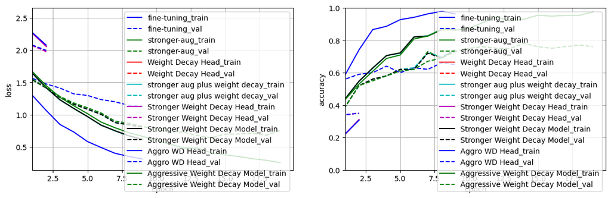

```python
fig, axes = plt.subplots(1, 2, figsize=(14, 4))
plt.sca(axes[0]); plotter(m_histories_6, metric='loss')
plt.sca(axes[1]); plotter(m_histories_6, metric='accuracy', ylim=[0.0, 1.0])
# plt.tight_layout(); plt.show()
```

Observation:

- validation loss started trending upwards after ~15 epochs, therefore overfitting
- Macro-F1 reached as high as 0.658 but plateued thereafter, finishing at 0.627

Decision:

- evaluate performance on class level, end experimentation on image-concatenation baseline model

Exporting histories as files:

```python
import json

with open('m_histories.json', 'w') as file:
    file.write(json.dumps(m_histories, indent=4))
with open('m_histories_2.json', 'w') as file:
    file.write(json.dumps(m_histories_2, indent=4))
with open('m_histories_3.json', 'w') as file:
    file.write(json.dumps(m_histories_2, indent=4))
with open('m_histories_4.json', 'w') as file:
    file.write(json.dumps(m_histories_2, indent=4))
with open('m_histories_5.json', 'w') as file:
    file.write(json.dumps(m_histories_2, indent=4))
with open('m_histories_6.json', 'w') as file:
    file.write(json.dumps(m_histories_2, indent=4))
```

Analysis:

```python
from sklearn.metrics import classification_report, confusion_matrix, ConfusionMatrixDisplay

model_ft.eval()
all_preds, all_labels = [], []
with torch.inference_mode():
    for x, y in val_loader:
        x = x.to(device)
        _, predicted = torch.max(model_ft(x), 1)
        all_preds.extend(predicted.cpu().numpy())
        all_labels.extend(y.numpy())

all_preds = np.array(all_preds)
all_labels = np.array(all_labels)

print(classification_report(all_labels, all_preds, target_names=class_name_list, zero_division=0.0))
```

```
                  precision    recall  f1-score   support

        AllClear       0.33      0.50      0.40         6
     HaveCommand       0.43      0.60      0.50         5
           Hover       1.00      1.00      1.00        16
            Land       0.68      1.00      0.81        17
LandingDirection       1.00      1.00      1.00         4
       MoveAhead       1.00      0.75      0.86         8
    MoveDownward       0.86      1.00      0.92         6
      MoveToLeft       1.00      1.00      1.00         7
     MoveToRight       1.00      1.00      1.00         6
      MoveUpward       0.00      0.00      0.00         7
        NotClear       0.00      0.00      0.00         6
        SlowDown       0.00      0.00      0.00         5
         WaveOff       0.50      1.00      0.67         6

        accuracy                           0.75        99
       macro avg       0.60      0.68      0.63        99
    weighted avg       0.66      0.75      0.69        99
```

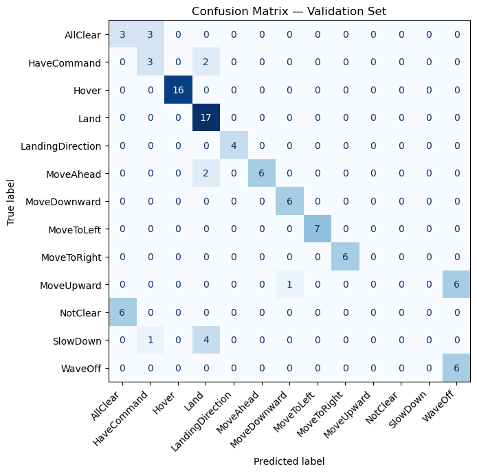

```python
cm = confusion_matrix(all_labels, all_preds)
fig, ax = plt.subplots(figsize=(8, 7))
disp = ConfusionMatrixDisplay(cm, display_labels=class_name_list)
disp.plot(ax=ax, xticks_rotation=45, cmap='Blues', colorbar=False)
plt.xticks(ha='right')
plt.title('Confusion Matrix — Validation Set')
plt.tight_layout()
plt.show()
```

```
Misclassified: 25 / 99 (25.3%)
```

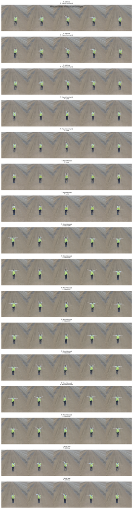

```python
# Separate unnormalised dataset for displaying validation images
vis_dataset = datasets.ImageFolder(
    val_dir,
    transform=transforms.Compose([
        transforms.Resize((IMG_HEIGHT, IMG_WIDTH)),
        transforms.ToTensor(),
    ])
)

# Confirm that displayed images use the same class-index mapping
assert vis_dataset.class_to_idx == val_ds.class_to_idx

errors = np.where(all_preds != all_labels)[0]

print(
    f'Misclassified: {len(errors)} / {len(all_labels)} '
    f'({len(errors) / len(all_labels) * 100:.1f}%)'
)

n_show = min(16, len(errors))

fig, axes = plt.subplots(16, 1, figsize=(16, 40))

for i, ax in enumerate(axes.flat):
    if i >= n_show:
        ax.axis('off')
        continue

    # errors[i] is already the index within the validation dataset
    val_idx = errors[i]
    img, _ = vis_dataset[val_idx]

    true_label = class_name_list[all_labels[val_idx]]
    predicted_label = class_name_list[all_preds[val_idx]]

    ax.imshow(img.permute(1, 2, 0).numpy())
    ax.set_title(
        f'T: {true_label}\nP: {predicted_label}',
        fontsize=8
    )
    ax.axis('off')

plt.suptitle('Misclassified Validation Images', fontsize=12)
plt.tight_layout()
plt.show()
```

Observation:

Suggestions:

- If NotClear were to be changed to a left-handed signal, it might become more easily distinguishable for the evaluated model, which is supported by the high f1-scores of MoveLeft and MoveRight, which are effectively horizontal flips of one-another. This suggestion is worth emphasising, as it is intuitively the most dangerous missclassification for a drone to be making, as the drone may move to land in an a manner that may harm people, other assets the drone comes into contact with, the cargo being carried by the drone, or the drone itself.
- If MoveUpward were to involve a greater separation of arms maintained, it might become more distinguishable for the evaluated model.

Final Evaluation - The Certificate

```python
def evaluate(model, loader, criterion):
    model.eval()
    total_loss, correct, total = 0.0, 0, 0
    with torch.inference_mode():
        for x, y in loader:
            x, y = x.to(device), y.to(device)
            outputs = model(x)
            loss = criterion(outputs, y)
            total_loss += loss.item() * y.size(0)
            _, predicted = torch.max(outputs, 1)
            correct += (predicted == y).sum().item()
            total += y.size(0)
    return total_loss / total, correct / total

test_ds = datasets.ImageFolder(test_dir, transform=val_transform)
test_loader = DataLoader(test_ds, batch_size=128, shuffle=False, num_workers=2)
metrics = {}
metrics = run_epoch(model_ft, test_loader, nn.CrossEntropyLoss())

print('=' * 60)
print('FINAL TEST SET EVALUATION')
print('=' * 60)
print(f'Test f1-score: {metrics["f1-score"]:.4f}')
print(f'Test Loss:     {metrics["loss"]:.4f}')
print(f'Target:        {0.80:.4f}')
print(f'Status:        {"✅ TARGET MET" if test_acc >= 0.80 else "❌ Below target"}')
print('=' * 60)
```

```
============================================================
FINAL TEST SET EVALUATION
============================================================
Test f1-score: 0.5999
Test Loss:     0.9335
Target:        0.8000
Status:        ❌ Below target
============================================================
```

```python
model_ft.eval()
test_preds, test_labels = [], []
with torch.inference_mode():
    for x, y in test_loader:
        x = x.to(device)
        _, predicted = torch.max(model_ft(x), 1)
        test_preds.extend(predicted.cpu().numpy())
        test_labels.extend(y.numpy())

print(classification_report(test_labels, test_preds, target_names=class_name_list, zero_division=0.0))
```

```
                  precision    recall  f1-score   support

        AllClear       1.00      0.44      0.62         9
     HaveCommand       0.00      0.00      0.00         5
           Hover       1.00      1.00      1.00        13
            Land       0.55      1.00      0.71        16
LandingDirection       1.00      1.00      1.00         5
       MoveAhead       0.00      0.00      0.00        10
    MoveDownward       0.41      1.00      0.58         7
      MoveToLeft       1.00      1.00      1.00         8
     MoveToRight       1.00      1.00      1.00         9
      MoveUpward       1.00      1.00      1.00         9
        NotClear       0.00      0.00      0.00         8
        SlowDown       0.00      0.00      0.00         7
         WaveOff       0.80      1.00      0.89         8

        accuracy                           0.69       114
       macro avg       0.60      0.65      0.60       114
    weighted avg       0.62      0.69      0.63       114
```

Development Summary (Macro-f1 Scores):

Final Test : 0.5999

Target : 0.800

## PART B

Executive Summary:

- Ensure all receivers are wearing **green hi-vis vests** and **dark-coloured pants**.
  - The model's training dataset exclusively contained subjects with such garments on.
  - Receivers without these garments would likely encounter less classification accuracy from the model.
- Ensure the receivers have **visually uncluttered backgrounds**.
  - Training subjects were standing on smooth dirt tracks.
  - Receivers standing in cluttered environments may experience worse accuracy.
- The model **cannot recognise "NotClear"**.
  - This signal is often misidentified as, "AllClear", as displayed by the Confusion Matrix.
  - Stress to receivers that their environment must be clear prior to the drone's arrival.
- The model **cannot recognise "SlowDown"**.
  - It would be safer to *always* reduce the drone's speed upon detecting a receiver.
  - The Confusion Matrix suggests it is often misinterpreted as "Land".
  - A drone that cannot slowdown in a dynamic environment, with moving people or vehicles, risks injury and damage to cargo.